# More Poisson

A [New York Times](http://www.nytimes.com/2012/03/25/us/death-and-disarray-at-americas-racetracks.html?pagewanted=all&_r=0) article in 2012 found that on average 24 horses die on US racetracks each week and from 2009 to 2012 and the US logged 5.2 incidents per 1,000 starts. What is the probability that between 0 and 40 horses will die in a week?

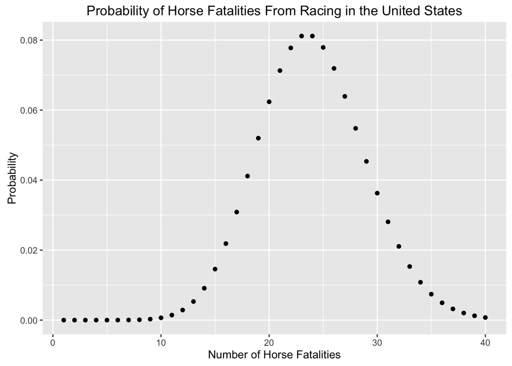

```r
library(ggplot2)
qplot(1:40,dpois(1:40,24), xlab="Number of Horse Fatalities", ylab="Probability", main="Probability of Horse Fatalities From Racing in the United States")
```

We can see that, for example, 30 horses could die in one week, the probability is about 3.6%. But is that unusual, and if 30 horses did die in one week does that mean that there’s been a significant and unusual increase in horse fatalities from racing and that something has made racing more dangerous for horses?

So what is the probability of getting 30 or more fatalities in one week? If we did `ppois(30-1, 24)` that would give us the probability of fewer than 30 fatalities in a week so `1-ppois(30-1,24)` OR `ppois(30-1, 24, lower.tail = FALSE)` gives us the probability of 30 or more fatalities in 1 week.

```r
ppois(30-1, 24, lower.tail = FALSE)
```

```
## [1] 0.1321236
```

So the probability is around 13%. We can multiply the number of weeks by 13% to see how many weeks in a year it is probable that 30 or more horses will die in one week.

```r
ppois(30-1, 24, lower.tail = FALSE) * 52
```

```
## [1] 6.870426
```

Which comes to around 7 weeks per year. This means that it’s likely that seven times per year there will be 30 or more horse fatalities in one week.